# Using CTCF occupied regions to define background regions for H3K36me3

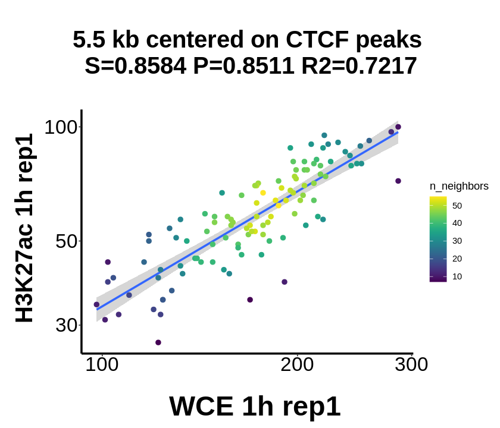

```r
#Don't print warnings
options(warn=-1);

options(jupyter.plot_mimetypes="image/png", repr.plot.width=7, repr.plot.height=6);

ggplot(df_1h_br1, mapping=aes(y = K27ac_1h_br1.Quant, x = WCE.K27ac_1h_br1.Quant)) + geom_point() +
    #The distance threshold to consider two points as neighbors (smoothing bandwidth) can be adjusted with the adjust argument,
    #where adjust = 0.5 means use half of the default bandwidth.
    geom_smooth(method='lm', formula= y~x) +
    geom_pointdensity(size = 2) +
    scale_color_viridis() +
    #geom_abline(alpha=0.4, col="black") +
    scale_x_log10() + scale_y_log10() +
    labs(
        title = paste0("\n 5.5 kb centered on CTCF peaks \n S=", round(ct.S_1h_br1$estimate,4), " P=", round(ct.P_1h_br1$estimate, 4), " R2=0.7217\n"),
        y = " H3K27ac 1h rep1",
        x = "  WCE 1h rep1"
    ) +
    theme_classic() +
    theme(
        #panel.border = element_blank(),
        # Remove panel background
        panel.background = element_blank(),
        legend.background = element_blank(),
        # Add axis line
        axis.line = element_line(colour = "black", size=1),
        panel.grid.major = element_line(colour = "white"),
        plot.title = element_text(color="black", size=24, face="bold", hjust = 0.5),
        axis.text.x = element_text( color="black", size=20, margin=margin(t = 1, r = 0, b = 2, l = 0)),
        axis.text.y = element_text( color="black", size=20, margin=margin(t = 0, r = 1, b = 0, l = 5)),
        axis.title.x = element_text(color="black", size=28, face="bold", margin = margin(t = 20, r = 0, b = 1, l = 0)),
        axis.title.y = element_text(color="black", size=24, face="bold", margin = margin(t = 0, r = 2, b = 0, l = 10))
    )
```

# *Timepoints 4h Rep1*

```r
#Summarise 20 quantiles
    K27ac_4h_br1.Quant     = getMatrixQuantiles(K27ac_4h_br1.perBin, 10);
    WCE.K27ac_4h_br1.Quant = getMatrixQuantiles(WCE.K27ac_4h_br1.perBin, 10);

#Make dataframe for plotting with ggplot
    df_4h_br1 = (data.frame(cbind(c(K27ac_4h_br1.Quant)),cbind(c(WCE.K27ac_4h_br1.Quant))));
    colnames(df_4h_br1) = c("K27ac_4h_br1.Quant", "WCE.K27ac_4h_br1.Quant");
```

```r
#Calculate correlations

ct.S_4h_br1=cor.test(df_4h_br1$K27ac_4h_br1.Quant, df_4h_br1$WCE.K27ac_4h_br1.Quant, method = "spearman");
ct.S_4h_br1$estimate

ct.P_4h_br1=cor.test(df_4h_br1$K27ac_4h_br1.Quant, df_4h_br1$WCE.K27ac_4h_br1.Quant, method = "pearson");
ct.P_4h_br1$estimate

#Fit linear model
lm(K27ac_4h_br1.Quant ~ WCE.K27ac_4h_br1.Quant, data=df_4h_br1)
```

**rho:** 0.846932407710082

**cor:** 0.852527772196137

```
Call:
lm(formula = K27ac_4h_br1.Quant ~ WCE.K27ac_4h_br1.Quant, data = df_4h_br1)

Coefficients:
           (Intercept)  WCE.K27ac_4h_br1.Quant
                4.2390                  0.3865
```

```r
summary(lm(K27ac_4h_br1.Quant ~ WCE.K27ac_4h_br1.Quant, data=df_4h_br1))
```

```
Call:
lm(formula = K27ac_4h_br1.Quant ~ WCE.K27ac_4h_br1.Quant, data = df_4h_br1)

Residuals:
     Min       1Q   Median       3Q      Max
-28.5182  -5.6565  -0.2204   5.5588  20.3965

Coefficients:
                       Estimate Std. Error t value Pr(>|t|)
(Intercept)              4.2390     3.4543   1.227    0.222
WCE.K27ac_4h_br1.Quant   0.3865     0.0228  16.951   <2e-16 ***
---
Signif. codes:  0 '***' 0.001 '**' 0.01 '*' 0.05 '.' 0.1 ' ' 1

Residual standard error: 8.802 on 108 degrees of freedom
Multiple R-squared:  0.7268,	Adjusted R-squared:  0.7243
F-statistic: 287.3 on 1 and 108 DF,  p-value: < 2.2e-16
```

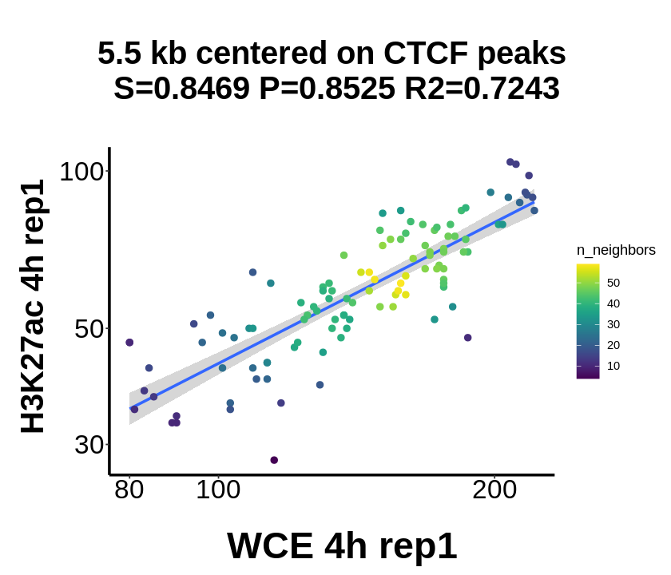

```r
#Don't print warnings
options(warn=-1);

options(jupyter.plot_mimetypes="image/png", repr.plot.width=7, repr.plot.height=6);

ggplot(df_4h_br1, mapping=aes(y = K27ac_4h_br1.Quant, x = WCE.K27ac_4h_br1.Quant)) + geom_point() +
    #The distance threshold to consider two points as neighbors (smoothing bandwidth) can be adjusted with the adjust argument,
    #where adjust = 0.5 means use half of the default bandwidth.
    geom_smooth(method='lm', formula= y~x) +
    geom_pointdensity(size = 2) +
    scale_color_viridis() +
    #geom_abline(alpha=0.4, col="black") +
    scale_x_log10() + scale_y_log10() +
    labs(
        title = paste0("\n 5.5 kb centered on CTCF peaks \n S=", round(ct.S_4h_br1$estimate,4), " P=", round(ct.P_4h_br1$estimate, 4), " R2=0.7243\n"),
        y = " H3K27ac 4h rep1",
        x = "  WCE 4h rep1"
    ) +
    theme_classic() +
    theme(
        #panel.border = element_blank(),
        # Remove panel background
        panel.background = element_blank(),
        legend.background = element_blank(),
        # Add axis line
        axis.line = element_line(colour = "black", size=1),
        panel.grid.major = element_line(colour = "white"),
        plot.title = element_text(color="black", size=24, face="bold", hjust = 0.5),
        axis.text.x = element_text( color="black", size=20, margin=margin(t = 1, r = 0, b = 2, l = 0)),
        axis.text.y = element_text( color="black", size=20, margin=margin(t = 0, r = 1, b = 0, l = 5)),
        axis.title.x = element_text(color="black", size=28, face="bold", margin = margin(t = 20, r = 0, b = 1, l = 0)),
        axis.title.y = element_text(color="black", size=24, face="bold", margin = margin(t = 0, r = 2, b = 0, l = 10))
    )
```

# *Timepoints 0h Rep2*

```r
#Summarise 20 quantiles
    K27ac_0h_br2.Quant     = getMatrixQuantiles(K27ac_0h_br2.perBin, 10);
    WCE.K27ac_0h_br2.Quant = getMatrixQuantiles(WCE.K27ac_0h_br2.perBin, 10);

#Make dataframe for plotting with ggplot
    df_0h_br2 = (data.frame(cbind(c(K27ac_0h_br2.Quant)),cbind(c(WCE.K27ac_0h_br2.Quant))));
    colnames(df_0h_br2) = c("K27ac_0h_br2.Quant", "WCE.K27ac_0h_br2.Quant");
```

```r
#Calculate correlations

ct.S_0h_br2=cor.test(df_0h_br2$K27ac_0h_br2.Quant, df_0h_br2$WCE.K27ac_0h_br2.Quant, method = "spearman");
ct.S_0h_br2$estimate

ct.P_0h_br2=cor.test(df_0h_br2$K27ac_0h_br2.Quant, df_0h_br2$WCE.K27ac_0h_br2.Quant, method = "pearson");
ct.P_0h_br2$estimate

#Fit linear model
lm(K27ac_0h_br2.Quant ~ WCE.K27ac_0h_br2.Quant, data=df_0h_br2)
```

**rho:** 0.784241096604345

**cor:** 0.772214261083175

```
Call:
lm(formula = K27ac_0h_br2.Quant ~ WCE.K27ac_0h_br2.Quant, data = df_0h_br2)

Coefficients:
           (Intercept)  WCE.K27ac_0h_br2.Quant
                2.3161                  0.3792
```

```r
summary(lm(K27ac_0h_br2.Quant ~ WCE.K27ac_0h_br2.Quant, data=df_0h_br2))
```

```
Call:
lm(formula = K27ac_0h_br2.Quant ~ WCE.K27ac_0h_br2.Quant, data = df_0h_br2)

Residuals:
     Min       1Q   Median       3Q      Max
-21.6696  -5.9698  -0.2469   6.1135  26.0554

Coefficients:
                       Estimate Std. Error t value Pr(>|t|)
(Intercept)             2.31610    4.21549   0.549    0.584
WCE.K27ac_0h_br2.Quant  0.37916    0.03002  12.631   <2e-16 ***
---
Signif. codes:  0 '***' 0.001 '**' 0.01 '*' 0.05 '.' 0.1 ' ' 1

Residual standard error: 10.09 on 108 degrees of freedom
Multiple R-squared:  0.5963,	Adjusted R-squared:  0.5926
F-statistic: 159.5 on 1 and 108 DF,  p-value: < 2.2e-16
```

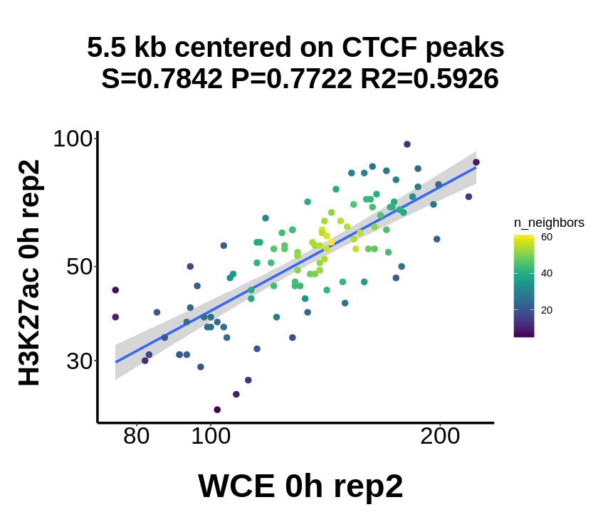

```r
#Don't print warnings
options(warn=-1);

options(jupyter.plot_mimetypes="image/png", repr.plot.width=7, repr.plot.height=6);

ggplot(df_0h_br2, mapping=aes(y = K27ac_0h_br2.Quant, x = WCE.K27ac_0h_br2.Quant)) + geom_point() +
    #The distance threshold to consider two points as neighbors (smoothing bandwidth) can be adjusted with the adjust argument,
    #where adjust = 0.5 means use half of the default bandwidth.
    geom_smooth(method='lm', formula= y~x) +
    geom_pointdensity(size = 2) +
    scale_color_viridis() +
    #geom_abline(alpha=0.4, col="black") +
    scale_x_log10() + scale_y_log10() +
    labs(
        title = paste0("\n 5.5 kb centered on CTCF peaks \n S=", round(ct.S_0h_br2$estimate,4), " P=", round(ct.P_0h_br2$estimate, 4), " R2=0.5926\n"),
        y = " H3K27ac 0h rep2",
        x = " WCE 0h rep2"
    ) +
    theme_classic() +
    theme(
        #panel.border = element_blank(),
        # Remove panel background
        panel.background = element_blank(),
        legend.background = element_blank(),
        # Add axis line
        axis.line = element_line(colour = "black", size=1),
        panel.grid.major = element_line(colour = "white"),
        plot.title = element_text(color="black", size=24, face="bold", hjust = 0.5),
        axis.text.x = element_text( color="black", size=20, margin=margin(t = 1, r = 0, b = 2, l = 0)),
        axis.text.y = element_text( color="black", size=20, margin=margin(t = 0, r = 1, b = 0, l = 5)),
        axis.title.x = element_text(color="black", size=28, face="bold", margin = margin(t = 20, r = 0, b = 1, l = 0)),
        axis.title.y = element_text(color="black", size=24, face="bold", margin = margin(t = 0, r = 2, b = 0, l = 10))
    )
```

# *Timepoints 1h Rep2*

```r
#Summarise 20 quantiles
    K27ac_1h_br2.Quant     = getMatrixQuantiles(K27ac_1h_br2.perBin, 10);
    WCE.K27ac_1h_br2.Quant = getMatrixQuantiles(WCE.K27ac_1h_br2.perBin, 10);

#Make dataframe for plotting with ggplot
    df_1h_br2 = (data.frame(cbind(c(K27ac_1h_br2.Quant)),cbind(c(WCE.K27ac_1h_br2.Quant))));
    colnames(df_1h_br2) = c("K27ac_1h_br2.Quant", "WCE.K27ac_1h_br2.Quant");
```

```r
#Calculate correlations

ct.S_1h_br2=cor.test(df_1h_br2$K27ac_1h_br2.Quant, df_1h_br2$WCE.K27ac_1h_br2.Quant, method = "spearman");
ct.S_1h_br2$estimate

ct.P_1h_br2=cor.test(df_1h_br2$K27ac_1h_br2.Quant, df_1h_br2$WCE.K27ac_1h_br2.Quant, method = "pearson");
ct.P_1h_br2$estimate

#Fit linear model
lm(K27ac_1h_br2.Quant ~ WCE.K27ac_1h_br2.Quant, data=df_1h_br2)
```

**rho:** 0.873942906569176

**cor:** 0.862601662282447

```
Call:
lm(formula = K27ac_1h_br2.Quant ~ WCE.K27ac_1h_br2.Quant, data = df_1h_br2)

Coefficients:
           (Intercept)  WCE.K27ac_1h_br2.Quant
                2.5212                  0.2484
```

```r
summary(lm(K27ac_1h_br2.Quant ~ WCE.K27ac_1h_br2.Quant, data=df_1h_br2))
```

```
Call:
lm(formula = K27ac_1h_br2.Quant ~ WCE.K27ac_1h_br2.Quant, data = df_1h_br2)

Residuals:
    Min      1Q  Median      3Q     Max
-27.213  -6.309   0.637   5.183  18.303

Coefficients:
                       Estimate Std. Error t value Pr(>|t|)
(Intercept)             2.52123    3.72569   0.677      0.5
WCE.K27ac_1h_br2.Quant  0.24840    0.01402  17.720   <2e-16 ***
---
Signif. codes:  0 '***' 0.001 '**' 0.01 '*' 0.05 '.' 0.1 ' ' 1

Residual standard error: 8.847 on 108 degrees of freedom
Multiple R-squared:  0.7441,	Adjusted R-squared:  0.7417
F-statistic:   314 on 1 and 108 DF,  p-value: < 2.2e-16
```

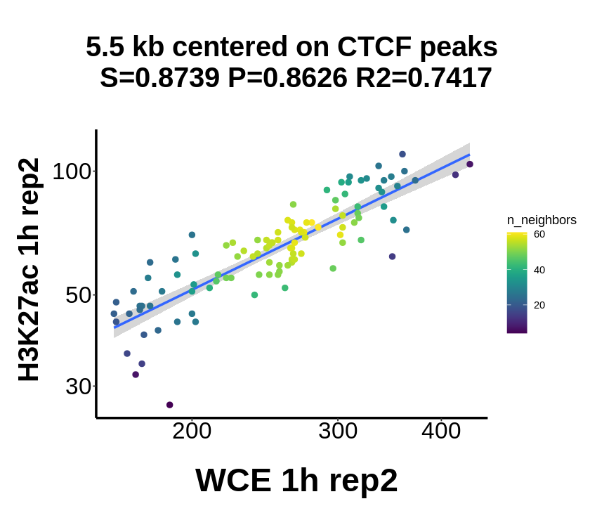

```r
#Don't print warnings
options(warn=-1);

options(jupyter.plot_mimetypes="image/png", repr.plot.width=7, repr.plot.height=6);

ggplot(df_1h_br2, mapping=aes(y = K27ac_1h_br2.Quant, x = WCE.K27ac_1h_br2.Quant)) + geom_point() +
    #The distance threshold to consider two points as neighbors (smoothing bandwidth) can be adjusted with the adjust argument,
    #where adjust = 0.5 means use half of the default bandwidth.
    geom_smooth(method='lm', formula= y~x) +
    geom_pointdensity(size = 2) +
    scale_color_viridis() +
    #geom_abline(alpha=0.4, col="black") +
    scale_x_log10() + scale_y_log10() +
    labs(
        title = paste0("\n 5.5 kb centered on CTCF peaks \n S=", round(ct.S_1h_br2$estimate,4), " P=", round(ct.P_1h_br2$estimate, 4), " R2=0.7417\n"),
        y = " H3K27ac 1h rep2",
        x = " WCE 1h rep2"
    ) +
    theme_classic() +
    theme(
        #panel.border = element_blank(),
        # Remove panel background
        panel.background = element_blank(),
        legend.background = element_blank(),
        # Add axis line
        axis.line = element_line(colour = "black", size=1),
        panel.grid.major = element_line(colour = "white"),
        plot.title = element_text(color="black", size=24, face="bold", hjust = 0.5),
        axis.text.x = element_text( color="black", size=20, margin=margin(t = 1, r = 0, b = 2, l = 0)),
        axis.text.y = element_text( color="black", size=20, margin=margin(t = 0, r = 1, b = 0, l = 5)),
        axis.title.x = element_text(color="black", size=28, face="bold", margin = margin(t = 20, r = 0, b = 1, l = 0)),
        axis.title.y = element_text(color="black", size=24, face="bold", margin = margin(t = 0, r = 2, b = 0, l = 10))
    )
```

# *Timepoints 4h Rep2*

```r
#Summarise 20 quantiles
    K27ac_4h_br2.Quant     = getMatrixQuantiles(K27ac_4h_br2.perBin, 10);
    WCE.K27ac_4h_br2.Quant = getMatrixQuantiles(WCE.K27ac_4h_br2.perBin, 10);

#Make dataframe for plotting with ggplot
    df_4h_br2 = (data.frame(cbind(c(K27ac_4h_br2.Quant)),cbind(c(WCE.K27ac_4h_br2.Quant))));
    colnames(df_4h_br2) = c("K27ac_4h_br2.Quant", "WCE.K27ac_4h_br2.Quant");
```

```r
#Calculate correlations

ct.S_4h_br2=cor.test(df_4h_br2$K27ac_4h_br2.Quant, df_4h_br2$WCE.K27ac_4h_br2.Quant, method = "spearman");
ct.S_4h_br2$estimate

ct.P_4h_br2=cor.test(df_4h_br2$K27ac_4h_br2.Quant, df_4h_br2$WCE.K27ac_4h_br2.Quant, method = "pearson");
ct.P_4h_br2$estimate

#Fit linear model
lm(K27ac_4h_br2.Quant ~ WCE.K27ac_4h_br2.Quant, data=df_4h_br2)
```

**rho:** 0.830634222748149

**cor:** 0.836285734422563

```
Call:
lm(formula = K27ac_4h_br2.Quant ~ WCE.K27ac_4h_br2.Quant, data = df_4h_br2)

Coefficients:
           (Intercept)  WCE.K27ac_4h_br2.Quant
                1.9113                  0.4106
```

```r
summary(lm(K27ac_4h_br2.Quant ~ WCE.K27ac_4h_br2.Quant, data=df_4h_br2))
```

```
Call:
lm(formula = K27ac_4h_br2.Quant ~ WCE.K27ac_4h_br2.Quant, data = df_4h_br2)

Residuals:
     Min       1Q   Median       3Q      Max
-29.5168  -5.6137  -0.3322   6.2051  30.2102

Coefficients:
                       Estimate Std. Error t value Pr(>|t|)
(Intercept)              1.9113     5.0204   0.381    0.704
WCE.K27ac_4h_br2.Quant   0.4106     0.0259  15.851   <2e-16 ***
---
Signif. codes:  0 '***' 0.001 '**' 0.01 '*' 0.05 '.' 0.1 ' ' 1

Residual standard error: 11.67 on 108 degrees of freedom
Multiple R-squared:  0.6994,	Adjusted R-squared:  0.6966
F-statistic: 251.3 on 1 and 108 DF,  p-value: < 2.2e-16
```

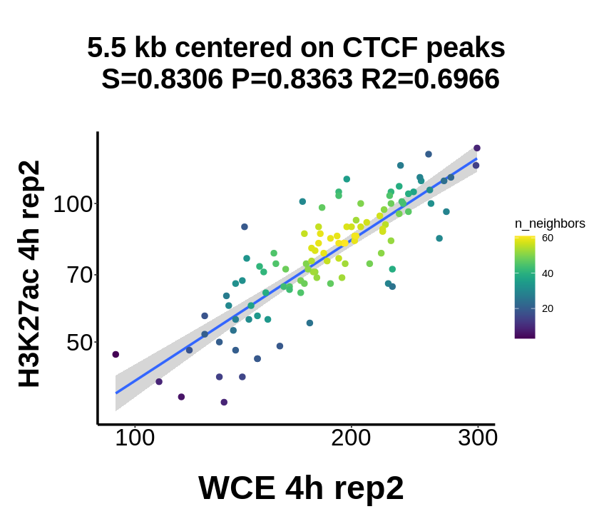

```r
#Don't print warnings
options(warn=-1);

options(jupyter.plot_mimetypes="image/png", repr.plot.width=7, repr.plot.height=6);

ggplot(df_4h_br2, mapping=aes(y = K27ac_4h_br2.Quant, x = WCE.K27ac_4h_br2.Quant)) + geom_point() +
    #The distance threshold to consider two points as neighbors (smoothing bandwidth) can be adjusted with the adjust argument,
    #where adjust = 0.5 means use half of the default bandwidth.
    geom_smooth(method='lm', formula= y~x) +
    geom_pointdensity(size = 2) +
    scale_color_viridis() +
    #geom_abline(alpha=0.4, col="black") +
    scale_x_log10() + scale_y_log10() +
    labs(
        title = paste0("\n 5.5 kb centered on CTCF peaks \n S=", round(ct.S_4h_br2$estimate,4), " P=", round(ct.P_4h_br2$estimate, 4), " R2=0.6966\n"),
        y = " H3K27ac 4h rep2",
        x = " WCE 4h rep2"
    ) +
    theme_classic() +
    theme(
        #panel.border = element_blank(),
        # Remove panel background
        panel.background = element_blank(),
        legend.background = element_blank(),
        # Add axis line
        axis.line = element_line(colour = "black", size=1),
        panel.grid.major = element_line(colour = "white"),
        plot.title = element_text(color="black", size=24, face="bold", hjust = 0.5),
        axis.text.x = element_text( color="black", size=20, margin=margin(t = 1, r = 0, b = 2, l = 0)),
        axis.text.y = element_text( color="black", size=20, margin=margin(t = 0, r = 1, b = 0, l = 5)),
        axis.title.x = element_text(color="black", size=28, face="bold", margin = margin(t = 20, r = 0, b = 1, l = 0)),
        axis.title.y = element_text(color="black", size=24, face="bold", margin = margin(t = 0, r = 2, b = 0, l = 10))
    )
```

# *Summary for H3K27ac* # center CTCF 80 kb from marks, 10 Quantiles, 5.5kb around CTCF, 500bp win (instead of 1kb) - No spike-in norm --> --> Works better than the 100kb w/o K27me3 - 0h Rep1: H3K27ac.signal = (0.87326 * WCE.signal) + 6.18404 - 1h Rep1: H3K27ac.signal = (0.3435 * WCE.signal) - 0.3084 - 4h Rep1: H3K27ac.signal = (0.3865 * WCE.signal) + 4.2390  
- 0h Rep2: H3K27ac.signal = (0.37916 * WCE.signal) + 2.31610 - 1h Rep2: H3K27ac.signal = (0.24840 * WCE.signal) + 2.52123 - 4h Rep2: H3K27ac.signal = (0.4106 * WCE.signal) + 1.9113  
## I have also tried:

[output not shown]

# `IIIb. Fit linear model for H3K36me3`:

```r
CTCF_peaks = read.table("/home/agc94/useful_genomeInfo/hg19/GSM935407_hg19_wgEncodeCTCFchip_SnyderLab.narrowPeak");
CTCF_peaks = CTCF_peaks[1:3];
colnames(CTCF_peaks) = c("chr", "start", "end");
CTCF_peaks = as(CTCF_peaks, "GRanges");

CTCF_peaks = resize(CTCF_peaks, width=80000, fix="center"); # --> 88141 peaks
```

```r
#1. Import gencode gene coordinates
    genes.coord = read.table("/local/storage/data/hg19/all/gencode/gencode.V19.annotation.txtable.out")[, c(1:3, 6)];
    colnames(genes.coord) = c("chr", "start", "end", "strand");
    genes.coord = makeGRangesFromDataFrame(genes.coord, keep.extra.columns = T);


#2. Import H3K27ac, H3K4me3, and H3K4me1 ENCODE peaks
    K27ac.peaks = read.table("/local/storage/data/hg19/k562/histones/wgEncodeBroadHistoneK562H3k27acStdPk.broadPeak")[, c(1:3)];
    K4me3.peaks = read.table(gzfile("/local/storage/data/hg19/k562/histones/wgEncodeBroadHistoneK562H3k4me3StdPk.broadPeak.gz"))[, c(1:3)];
    K4me1.peaks = read.table(gzfile("/local/storage/data/hg19/k562/histones/wgEncodeBroadHistoneK562H3k4me1StdPk.broadPeak.gz"))[, c(1:3)];
    #K27me3.peaks = read.table(gzfile("/local/storage/data/hg19/k562/histones/wgEncodeBroadHistoneK562H3k27me3StdPk.broadPeak.gz"))[, c(1:3)];

    #dREG peaks in K562
    K562.dreg = read.table(gzfile("/local/storage/data/hg19/k562/dreg/G1.dREG.peak.full.bed.gz"))[, c(1:3)];

    #My set of peaks called using MACS2 (qval<0.1)
    K27ac.MyPeaks = read.table(gzfile("/local/storage/projects/RawSequenceFiles/2019-07-06_K562_ChIP_TriptolideTimecourse/merged_datasets_JuneJuly2019/masked_Diulia/BAM_files/K27ac_bam/K27ac_masterBAM_peaks.narrowPeak.gz"))[, c(1:3)];
    K4me3.MyPeaks = read.table(gzfile("/local/storage/projects/RawSequenceFiles/2019-07-06_K562_ChIP_TriptolideTimecourse/merged_datasets_JuneJuly2019/masked_Diulia/BAM_files/K4me3_bam/K4me3_masterBAM_peaks.narrowPeak.gz"))[, c(1:3)];
    K4me1.MyPeaks = read.table(gzfile("/local/storage/projects/RawSequenceFiles/2019-07-06_K562_ChIP_TriptolideTimecourse/merged_datasets_JuneJuly2019/masked_Diulia/BAM_files/K4me1_bam/K4me1_masterBAM_peaks.narrowPeak.gz"))[, c(1:3)];

    #Rename the columns of each file and convert to GRanges
    colnames(K27ac.peaks) = c("chr", "start", "end");
    colnames(K4me3.peaks) = c("chr", "start", "end");
    colnames(K4me1.peaks) = c("chr", "start", "end");
    #colnames(K27me3.peaks) = c("chr", "start", "end");

    colnames(K562.dreg) = c("chr", "start", "end");
    colnames(K27ac.MyPeaks) = c("chr", "start", "end");
    colnames(K4me3.MyPeaks) = c("chr", "start", "end");
    colnames(K4me1.MyPeaks) = c("chr", "start", "end");



    K27ac.peaks = makeGRangesFromDataFrame(K27ac.peaks);
    K4me3.peaks = makeGRangesFromDataFrame(K4me3.peaks);
    K4me1.peaks = makeGRangesFromDataFrame(K4me1.peaks);
    #K27me3.peaks = makeGRangesFromDataFrame(K27me3.peaks);

    K562.dreg = makeGRangesFromDataFrame(K562.dreg);

    K27ac.MyPeaks = makeGRangesFromDataFrame(K27ac.MyPeaks);
    K4me3.MyPeaks = makeGRangesFromDataFrame(K4me3.MyPeaks);
    K4me1.MyPeaks = makeGRangesFromDataFrame(K4me1.MyPeaks);



#3. Merge gthe coordinates of genes with H3K27ac, H3K4me3, and H3K4me1 ENCODE broad peaks
    marks = append(genes.coord, K4me1.peaks);
    marks = append(marks      , K4me1.MyPeaks);
    marks = append(marks      , K27ac.MyPeaks);
    marks = append(marks      , K27ac.peaks);

    marks = append(marks      , K4me3.MyPeaks);
    marks = append(marks      , K4me3.peaks);
    marks = append(marks      , K562.dreg);



#4. Find CTCF-1kb regions that fall within genes
    hits = findOverlaps(marks, CTCF_peaks);
    CTCF_peaks$InsideGene = FALSE;
    CTCF_peaks$InsideGene[hits@to] = TRUE

    #Keep only CTCF regions outside genes
    CTCF_peaks = CTCF_peaks[CTCF_peaks$InsideGene == FALSE];  #--> 1592 CTCF peaks left
```

```r
#8. Avoid taking into account regions with high DHS scores: regions at the TSS (high MNase cutting efficiency)
    CTCF_peaks.bp = resize(CTCF_peaks, width = 1, fix = "center");
    CTCF_peaks.bp.toRemove = CTCF_peaks.bp + 1000;

    #Resize each CTCF peaks to 1-bp start position & 1-bp end position of each peak
    CTCF_peaks.bp.plus5kb = resize(CTCF_peaks.bp.toRemove, width=1, fix="end");
    CTCF_peaks.bp.minus5kb = resize(CTCF_peaks.bp.toRemove, width=1, fix="start");

    #Take regions adjacent to the 4kb TSS: meaning, take 10kb in each direction from the CTCF center position & avoid 4kb around TSS
    CTCF_peaks.bp.minus5kb = promoters(CTCF_peaks.bp.minus5kb, upstream=10000, downstream=0)
    CTCF_peaks.bp.plus5kb = promoters(CTCF_peaks.bp.plus5kb, upstream=0, downstream=10000)

    #Merge the 2 regions
    CTCF_peaks.K4me1 = c(CTCF_peaks.bp.plus5kb, CTCF_peaks.bp.minus5kb);

CTCF_peaks.K4me1
```

```
GRanges object with 3184 ranges and 1 metadata column:
         seqnames              ranges strand | InsideGene
            <Rle>           <IRanges>  <Rle> |  <logical>
     [1]    chr13   53543430-53553429      * |      FALSE
     [2]     chr2   17082758-17092757      * |      FALSE
     [3]     chr2   31086097-31096096      * |      FALSE
     [4]    chr20   11994084-12004083      * |      FALSE
     [5]    chr12   59544991-59554990      * |      FALSE
     ...      ...                 ...    ... .        ...
  [3180]     chr7 153522163-153532162      * |      FALSE
  [3181]     chr4   12400640-12410639      * |      FALSE
  [3182]     chr2 123170686-123180685      * |      FALSE
  [3183]     chr2 151632259-151642258      * |      FALSE
  [3184]     chr2 235509057-235519056      * |      FALSE
  -------
  seqinfo: 23 sequences from an unspecified genome; no seqlengths
```

```r
#5. Add an column with a separate ID for each CTCF peak in CTCF_peaks
CTCF_peaks.K4me1$CTCF.overlap = c(1:length(CTCF_peaks.K4me1));
CTCF_peaks.K4me1
```

```
GRanges object with 3184 ranges and 2 metadata columns:
         seqnames              ranges strand | InsideGene CTCF.overlap
            <Rle>           <IRanges>  <Rle> |  <logical>    <integer>
     [1]    chr13   53543430-53553429      * |      FALSE            1
     [2]     chr2   17082758-17092757      * |      FALSE            2
     [3]     chr2   31086097-31096096      * |      FALSE            3
     [4]    chr20   11994084-12004083      * |      FALSE            4
     [5]    chr12   59544991-59554990      * |      FALSE            5
     ...      ...                 ...    ... .        ...          ...
  [3180]     chr7 153522163-153532162      * |      FALSE         3180
  [3181]     chr4   12400640-12410639      * |      FALSE         3181
  [3182]     chr2 123170686-123180685      * |      FALSE         3182
  [3183]     chr2 151632259-151642258      * |      FALSE         3183
  [3184]     chr2 235509057-235519056      * |      FALSE         3184
  -------
  seqinfo: 23 sequences from an unspecified genome; no seqlengths
```

```r
#6. #Import DNase-I hypersensitivity BAM in K562 cells
    load("/local/storage/data/hg19/k562/dnase/GSM646567_hg19_wgEncodeUwDgfK562Aln.Rdata");
    DNase_peaks = reads;
    rm(reads)
    #Make DNAse BRG object
    DNase_peaks = resize(DNase_peaks, width = 1, fix = "center");
    DNase_peaks = GRanges(coverage(DNase_peaks, weight="count"));
    DNase_peaks = makeGRangesBRG(DNase_peaks[DNase_peaks$score > 0]);

    #Count DHS signal within each CTCF peak
    CTCF_peaks.K4me1$DHS.score = getCountsByRegions(DNase_peaks, CTCF_peaks.K4me1, field="score");

    #Order the CTCF peaks based on the number of DHS reads falling within each peak
    CTCF_peaks.K4me1.order = sort(CTCF_peaks.K4me1, by = ~ DHS.score);
```

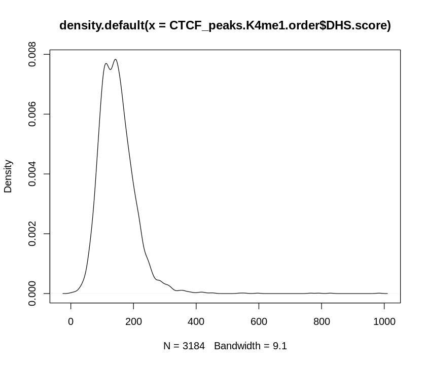

```r
#7. Plot histogram of DHS signal
    plot(density(CTCF_peaks.K4me1.order$DHS.score))
```

```r
CTCF_peaks.K4me1.order
```

```
GRanges object with 3184 ranges and 3 metadata columns:
         seqnames              ranges strand | InsideGene CTCF.overlap
            <Rle>           <IRanges>  <Rle> |  <logical>    <integer>
     [1]     chrX   62349143-62359142      * |      FALSE          671
     [2]     chrX   76652781-76662780      * |      FALSE          963
     [3]     chr9   92670739-92680738      * |      FALSE         2084
     [4]    chr21     9591347-9601346      * |      FALSE          433
     [5]     chrX   57832951-57842950      * |      FALSE         2138
     ...      ...                 ...    ... .        ...          ...
  [3180]     chrX 110076779-110086778      * |      FALSE         2057
  [3181]    chr11   54952005-54962004      * |      FALSE         1499
  [3182]    chr11   54954494-54964493      * |      FALSE         2680
  [3183]    chr19   24391950-24401949      * |      FALSE         1392
  [3184]     chr8   43718453-43728452      * |      FALSE          856
         DHS.score
         <integer>
     [1]         2
     [2]        10
     [3]        12
     [4]        19
     [5]        24
     ...       ...
  [3180]       596
  [3181]       765
  [3182]       791
  [3183]       828
  [3184]       983
  -------
  seqinfo: 23 sequences from an unspecified genome; no seqlengths
```

```r
#1. Import H3K36me3 and WCE BAMs (as Rdata)
    load("/local/storage/projects/RawSequenceFiles/2019-07-06_K562_ChIP_TriptolideTimecourse/merged_datasets_JuneJuly2019/masked_Diulia/BAM_files/K36me3_bam/mergedMasked_realK36me3_0h_br1.Rdata");
    K36me3_0h_br1 = reads;
    rm(reads)

    load("/local/storage/projects/RawSequenceFiles/2019-07-06_K562_ChIP_TriptolideTimecourse/merged_datasets_JuneJuly2019/masked_Diulia/BAM_files/K36me3_bam/mergedMasked_K36me3_1h_br1.Rdata");
    K36me3_1h_br1 = reads;
    rm(reads)

    load("/local/storage/projects/RawSequenceFiles/2019-07-06_K562_ChIP_TriptolideTimecourse/merged_datasets_JuneJuly2019/masked_Diulia/BAM_files/K36me3_bam/mergedMasked_K36me3_4h_br1.Rdata");
    K36me3_4h_br1 = reads;
    rm(reads)


    load("/local/storage/projects/RawSequenceFiles/2019-07-06_K562_ChIP_TriptolideTimecourse/merged_datasets_JuneJuly2019/masked_Diulia/BAM_files/K36me3_bam/mergedMasked_K36me3_0h_br2.Rdata");
    K36me3_0h_br2 = reads;
    rm(reads)

    load("/local/storage/projects/RawSequenceFiles/2019-07-06_K562_ChIP_TriptolideTimecourse/merged_datasets_JuneJuly2019/masked_Diulia/BAM_files/K36me3_bam/mergedMasked_K36me3_1h_br2.Rdata");
    K36me3_1h_br2 = reads;
    rm(reads)

    load("/local/storage/projects/RawSequenceFiles/2019-07-06_K562_ChIP_TriptolideTimecourse/merged_datasets_JuneJuly2019/masked_Diulia/BAM_files/K36me3_bam/mergedMasked_K36me3_4h_br2.Rdata");
    K36me3_4h_br2 = reads;
    rm(reads)


    #WCE
    load("/local/storage/projects/RawSequenceFiles/2019-07-06_K562_ChIP_TriptolideTimecourse/WCE_mergedBAMs_JuneJulyOct2019/BAM_files/WCE_0h_br1_JJO19.Rdata");
    WCE_0h_br1 = reads;
    rm(reads)

    load("/local/storage/projects/RawSequenceFiles/2019-07-06_K562_ChIP_TriptolideTimecourse/WCE_mergedBAMs_JuneJulyOct2019/BAM_files/WCE_1h_br1_JJO19.Rdata");
    WCE_1h_br1 = reads;
    rm(reads)

    load("/local/storage/projects/RawSequenceFiles/2019-07-06_K562_ChIP_TriptolideTimecourse/WCE_mergedBAMs_JuneJulyOct2019/BAM_files/WCE_4h_br1_JJO19.Rdata");
    WCE_4h_br1 = reads;
    rm(reads)


    load("/local/storage/projects/RawSequenceFiles/2019-07-06_K562_ChIP_TriptolideTimecourse/WCE_mergedBAMs_JuneJulyOct2019/BAM_files/WCE_0h_br2_JJO19.Rdata");
    WCE_0h_br2 = reads;
    rm(reads)

    load("/local/storage/projects/RawSequenceFiles/2019-07-06_K562_ChIP_TriptolideTimecourse/WCE_mergedBAMs_JuneJulyOct2019/BAM_files/WCE_1h_br2_JJO19.Rdata");
    WCE_1h_br2 = reads;
    rm(reads)

    load("/local/storage/projects/RawSequenceFiles/2019-07-06_K562_ChIP_TriptolideTimecourse/WCE_mergedBAMs_JuneJulyOct2019/BAM_files/WCE_4h_br2_JJO19.Rdata");
    WCE_4h_br2 = reads;
    rm(reads)
```

```r
Count.reads.InBins = function(mark.BAM, regions, spike = 1, binsize = 1, field = "score"){
    #Spike-in normalize the BAMs
    #mark.BAM$count = mark.BAM$count / spike;
    #Resize each read from BAM to 1bp (center position of each read)
    mark.BAM.res = resize(mark.BAM, width = 1, fix = "center");
    #Compute coverage
    mark.BAM.res = GRanges(coverage(mark.BAM.res, weight="count"));
    mark.BAM.res = makeGRangesBRG(mark.BAM.res[mark.BAM.res$score > 0]);

    #Count DHS signal within each CTCF peak
    mark.BAM.score = getCountsByPositions(mark.BAM.res, regions, binsize = binsize, field="score");

    return(mark.BAM.score/spike)
}
```

```r
#0h Rep1
#4. Experimental H3K36me3 signal in regions of interest
    K36me3_0h_br1.perBin     = Count.reads.InBins(K36me3_0h_br1, CTCF_peaks.K4me1.order, spike = 1,  binsize = 500, field = "score");
    K36me3_1h_br1.perBin     = Count.reads.InBins(K36me3_1h_br1, CTCF_peaks.K4me1.order, spike = 1,  binsize = 500, field = "score");
    K36me3_4h_br1.perBin     = Count.reads.InBins(K36me3_4h_br1, CTCF_peaks.K4me1.order, spike = 1,  binsize = 500, field = "score");

    K36me3_0h_br2.perBin     = Count.reads.InBins(K36me3_0h_br2, CTCF_peaks.K4me1.order, spike = 1,  binsize = 500, field = "score");
    K36me3_1h_br2.perBin     = Count.reads.InBins(K36me3_1h_br2, CTCF_peaks.K4me1.order, spike = 1,  binsize = 500, field = "score");
    K36me3_4h_br2.perBin     = Count.reads.InBins(K36me3_4h_br2, CTCF_peaks.K4me1.order, spike = 1,  binsize = 500, field = "score");
```

```r
WCE.K36me3_0h_br1.perBin = Count.reads.InBins(WCE_0h_br1,    CTCF_peaks.K4me1.order, spike = 1,  binsize = 500, field = "score");
    WCE.K36me3_1h_br1.perBin = Count.reads.InBins(WCE_1h_br1,    CTCF_peaks.K4me1.order, spike = 1,  binsize = 500, field = "score");
    WCE.K36me3_4h_br1.perBin = Count.reads.InBins(WCE_4h_br1,    CTCF_peaks.K4me1.order, spike = 1,  binsize = 500, field = "score");

    WCE.K36me3_0h_br2.perBin = Count.reads.InBins(WCE_0h_br2,    CTCF_peaks.K4me1.order, spike = 1,  binsize = 500, field = "score");
    WCE.K36me3_1h_br2.perBin = Count.reads.InBins(WCE_1h_br2,    CTCF_peaks.K4me1.order, spike = 1,  binsize = 500, field = "score");
    WCE.K36me3_4h_br2.perBin = Count.reads.InBins(WCE_4h_br2,    CTCF_peaks.K4me1.order, spike = 1,  binsize = 500, field = "score");
```